# The Commercial Consequences of Collective Layoffs: Close the Plant, Lose the Brand?

Page 1

Article

## The Commercial Consequences of Collective Layoffs: Close the Plant, Lose the Brand?

#### Vardit Landsman and Stefan Stremersch

Abstract This article examines the effects of collective layoff announcements on sales and marketing-mix elasticities, accounting for supplyside constraints. The authors study 205 announcements in the automotive industry using a difference-in-differences model. They find that, following collective layoff announcements, layoff firms experience adverse changes in sales, advertising elasticity, and price elasticity. They explore the moderating role of announcement characteristics on these changes and find that collective layoff announcements by domestic firms and announcements that do not mention a decline in demand as a motive are more likely to be followed by adverse marketing-mix elasticity changes. On average, sales for the layoff firm in the layoff country are 8.7% lower following a collective layoff announcement than their predicted levels absent the announcement. Similarly, advertising elasticity is 9.8% lower and price elasticity is 19.2% higher than absent the announcement. Conversely, layoff firms typically decrease advertising spending in the country where collective layoffs have occurred, yet they do not change prices. These findings are relevant to marketing managers of firms undergoing collective layoffs and to analysts of collective layoff decisions.

Keywords advertising, collective layoffs, difference-in-differences, downsizing, marketing-mix elasticity, price, pricing, sales

Online supplement: https://doi.org/10.1177/0022242919901277

Collective layoffs—the simultaneous termination of the labor contracts of a large group of workers—are common in many Western societies (Datta et al. 2010). In Europe alone, 556 collective layoffs were announced between December 2018 and November 2019, involving more than 250,000 employees (Eurofound 2019). In addition to their societal implications, collective layoff decisions have an immense impact on the firms that initiate them.

Management scholars have studied the financial consequences of collective layoffs for downsizing firms (“layoff firms”) as well as for their employees (see, e.g., Guthrie and Datta 2008; Morrison and Robinson 1997; Shah 2000). In marketing, prior research has studied various aspects of customer or investor response to collective layoffs (see Table 1). These studies, which mostly focused on layoffs of customer-facing employees, have shown, for example, that downsizing can increase customer uncertainty, decrease firms’ customer orientation and customers’ positive perceptions of the brand, and decrease customer satisfaction (Habel and Klarmann 2015; Homburg, Klarmann, and Staritz 2012; Subramony and Holtom 2012).

The present research complements this prior work in management and marketing by being the first to empirically

demonstrate the effects of collective layoff announcements on demand and the effectiveness of its drivers (i.e., marketing-mix elasticities). Given that termination of employment, particularly of large numbers of people, typically evokes negative connotations, it seems reasonable to expect that layoff announcements should have negative, rather than positive, effects on the layoff firm’s demand. Nevertheless, we do not know whether such negative demand effects are universally present (i.e., in how many cases do collective layoffs typically lead to lower demand?) and what the magnitude is of such demand effects (i.e., are these effects typically very large or typically rather small?). Moreover, the measurement of these effects is not straightforward, as the methodology used must control for factors such as production capacity constraints, which are likely to result from staff downsizing, as well as for

Vardit Landsman is Professor of Marketing, Erasmus School of Economics, Erasmus University Rotterdam, Netherlands (email: landsman@ese.eur.nl). Stefan Stremersch is Chair of Marketing and Desiderius Erasmus Distinguished Chair of Economics, Erasmus School of Economics, Erasmus University Rotterdam, Netherlands, and Professor of Marketing, IESE Business School, Universidad de Navarra, Spain (email: stremersch@ese.eur.nl).

Page 2

Table 1. Review: Marketing Studies on Employee Downsizing.

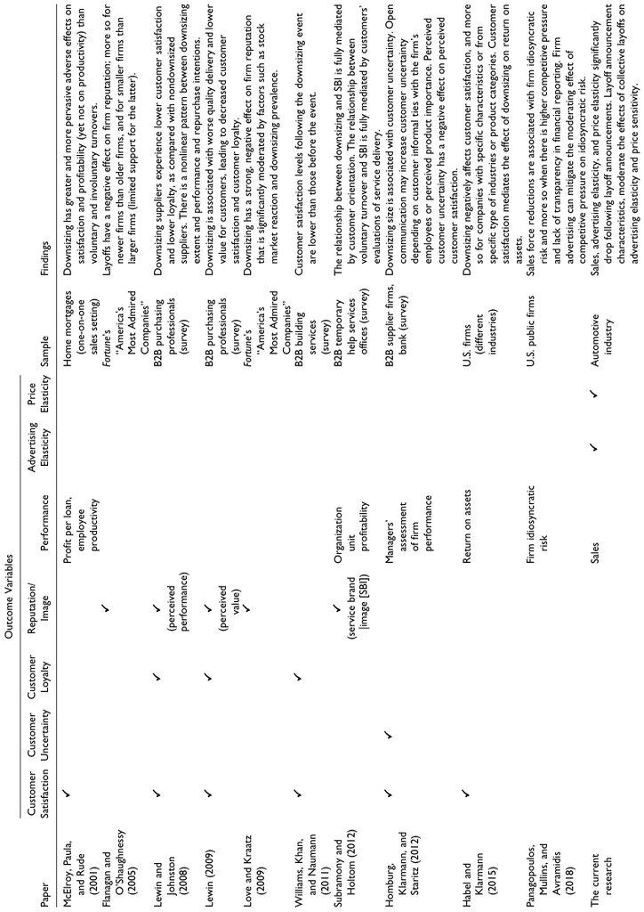

NOTE: complex table shown as an image of the PDF; the text below is a rough machine extraction and may be mis-aligned.

**extracted text (unreliable layout)**

Notes: B2B ¼ business to business.

123

Page 3

potentially endogenous relationships between collective layoff announcements and various marketing decisions that might influence demand.

The effects of collective layoffs on the elasticities of marketing-mix components (e.g., advertising and price elasticities) are also unknown at present and are not simple to predict. For instance, consider advertising. On the one hand, a firm that announces a collective layoff may create uncertainty among consumers (Homburg, Klarmann, and Staritz 2012); as a result, consumers may rely more heavily on the firm’s advertising as a source of information that might mitigate such uncertainty—thereby increasing advertising elasticity. On the other hand, a firm that announces a collective layoff may be viewed as being unfair to workers (Skarlicki, Ellard and Kelln 1998), making the firm less likeable and trustworthy—thereby decreasing advertising elasticity (Colicev et al. 2018, Van Heerde, Helsen, and Dekimpe 2007). Given that such opposing forces are at play, the extent to which firm marketing instruments (e.g., advertising) are expected to dampen any adverse demand effects caused by the announcement of a collective layoff is not obvious. Moreover, thus far, the marketing literature has given no empirically validated guidance in this regard. This study aims to provide such insights, toward supporting firms’ decision making with regard to marketing instruments in the country where the collective layoffs take place.

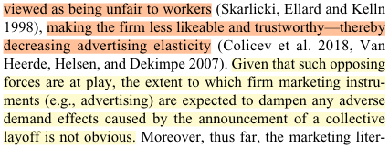

NOTE: figure/graphic rendered as an image from the PDF; its content is not machine-readable text. Caption (if any) follows as the next block.

Taking a broader perspective, this article complements the scholarly insights provided by prior studies on the commercial consequences of other types of firm crises. For instance, previous research has investigated the impact of product harm crises (e.g., Cleeren, Van Heerde, and Dekimpe 2013; Liu and Shankar 2015), firms’ violations of ethical or moral norms such as sweatshop operations (Bartley and Child 2011; Huber et al. 2010), or negative news on celebrities who have endorsed a particular brand (Knittel and Stango 2013). However, collective layoffs have several unique characteristics that distinguish them from other crisis types, and thus, the commercial consequences of such layoffs warrant specific consideration.

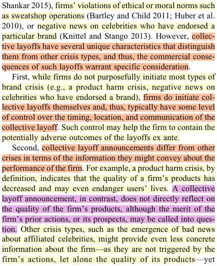

NOTE: figure/graphic rendered as an image from the PDF; its content is not machine-readable text. Caption (if any) follows as the next block.

**text found inside the figure**

First, while firms do not purposefully initiate most types of brand crisis (e.g., a product harm crisis, negative news on celebrities who have endorsed a brand), firms do initiate collective layoffs themselves and, thus, typically have some level of control over the timing, location, and communication of the collective layoff. Such control may help the firm to contain the potentially adverse outcomes of the layoffs ex ante.

Second, collective layoff announcements differ from other crises in terms of the information they might convey about the performance of the firm. For example, a product harm crisis, by definition, indicates that the quality of a firm’s products has decreased and may even endanger users’ lives. A collective layoff announcement, in contrast, does not directly reflect on the quality of the firm’s products, although the merit of the firm’s prior actions, or its prospects, may be called into question. Other crisis types, such as the emergence of bad news about affiliated celebrities, might provide even less concrete information about the firm—as they are not triggered by the firm’s actions, let alone the quality of its products—yet

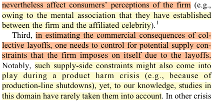

NOTE: figure/graphic rendered as an image from the PDF; its content is not machine-readable text. Caption (if any) follows as the next block.

**text found inside the figure**

nevertheless affect consumers’ perceptions of the firm (e.g., owing to the mental association that they have established between the firm and the affiliated celebrity).<sup>1</sup>

Third, in estimating the commercial consequences of collective layoffs, one needs to control for potential supply constraints that the firm imposes on itself due to the layoffs. Notably, such supply-side constraints might also come into play during a product harm crisis (e.g., because of production-line shutdowns), yet, to our knowledge, studies in this domain have rarely taken them into account. In other crisis types, supply-side constraints are less likely to affect the estimation of commercial consequences.

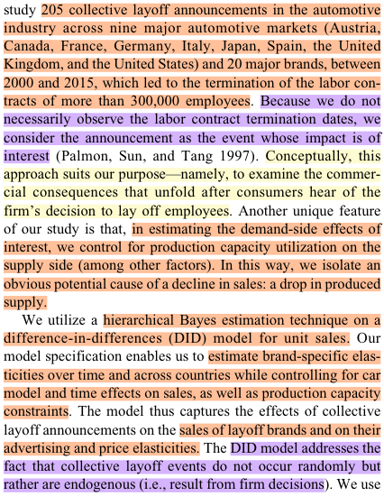

NOTE: figure/graphic rendered as an image from the PDF; its content is not machine-readable text. Caption (if any) follows as the next block.

**text found inside the figure**

With the aim of providing an initial empirical generalization on the commercial consequences of collective layoffs, we study 205 collective layoff announcements in the automotive industry across nine major automotive markets (Austria, Canada, France, Germany, Italy, Japan, Spain, the United Kingdom, and the United States) and 20 major brands, between 2000 and 2015, which led to the termination of the labor contracts of more than 300,000 employees. Because we do not necessarily observe the labor contract termination dates, we consider the announcement as the event whose impact is of interest (Palmon, Sun, and Tang 1997). Conceptually, this approach suits our purpose—namely, to examine the commercial consequences that unfold after consumers hear of the firm’s decision to lay off employees. Another unique feature of our study is that, in estimating the demand-side effects of interest, we control for production capacity utilization on the supply side (among other factors). In this way, we isolate an obvious potential cause of a decline in sales: a drop in produced supply.

We utilize a hierarchical Bayes estimation technique on a difference-in-differences (DID) model for unit sales. Our model specification enables us to estimate brand-specific elasticities over time and across countries while controlling for car model and time effects on sales, as well as production capacity constraints. The model thus captures the effects of collective layoff announcements on the sales of layoff brands and on their advertising and price elasticities. The DID model addresses the fact that collective layoff events do not occur randomly but rather are endogenous (i.e., result from firm decisions). We use a system of equations together with instrumentation to address the endogeneity of advertising and pricing and to account for common unobserved shocks that may influence sales, advertising, and price levels.

Our rich data together with our modeling framework also enable us to explore the heterogeneity of our main effects of interest (demand, advertising elasticity, and price elasticity) across characteristics of the layoff announcements and to identify boundary conditions. From our analysis of the content of

1 In the case of bad news about affiliated celebrities, one could argue that the firm should have better vetted the celebrities they endorse, yet these are secondary concerns compared with direct performance concerns such as those resulting from a product harm crisis.

124 Journal of Marketing 84(3)

Page 4

these announcements and the events they cover, we identify three information components that an announcement typically contains and that seem worthy of exploration: (1) motive (did the firm motivate the collective layoff by a decline in demand or by other reasons [e.g., a supply-side search for efficiency gains]?), (2) nationality (is the firm domestic [and thus considered an in-group actor] or foreign [and thus considered an outgroup actor] to the layoff country?), and (3) layoff size (how many employees are affected by the collective layoff?). While we do not claim that this is an exhaustive set of factors that might moderate the effects we explore, we believe that investigation of these factors can deliver some first insights that may stimulate further research to shed light on mediation and moderation processes regarding the commercial consequences of collective layoffs.

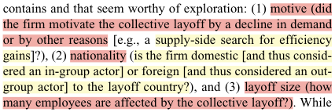

NOTE: figure/graphic rendered as an image from the PDF; its content is not machine-readable text. Caption (if any) follows as the next block.

We report the following findings, which are new to the literature. First, using model-free evidence, we show that for two-thirds of the collective layoff announcements in our sample, the sales of the corresponding brands in the layoff country decreased in the year following the announcements as compared with sales in the year before the announcements. The mean drop in sales across all announcements was 6.6%. Our model estimates enable us to demonstrate that, accounting for all other effects in our model—including changes in marketingmix elasticities and changes in advertising spending by layoff firms in the layoff country—sales for the layoff brand are 8.7% lower following a layoff announcement than their predicted levels absent the announcement.

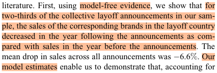

NOTE: figure/graphic rendered as an image from the PDF; its content is not machine-readable text. Caption (if any) follows as the next block.

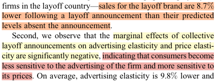

NOTE: figure/graphic rendered as an image from the PDF; its content is not machine-readable text. Caption (if any) follows as the next block.

Second, we observe that the marginal effects of collective layoff announcements on advertising elasticity and price elasticity are significantly negative, indicating that consumers become less sensitive to the advertising of the firm and more sensitive to its prices. On average, advertising elasticity is 9.8% lower and price elasticity is 19.2% higher (a more negative price elasticity) than absent the announcement. These effects are moderated by the layoff announcement characteristics we investigate.

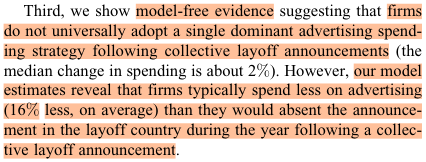

NOTE: figure/graphic rendered as an image from the PDF; its content is not machine-readable text. Caption (if any) follows as the next block.

**text found inside the figure**

Third, we show model-free evidence suggesting that firms do not universally adopt a single dominant advertising spending strategy following collective layoff announcements (the median change in spending is about 2%). However, our model estimates reveal that firms typically spend less on advertising (16% less, on average) than they would absent the announcement in the layoff country during the year following a collective layoff announcement.

[figure not shown]

NOTE: figure/graphic rendered as an image from the PDF; its content is not machine-readable text. Caption (if any) follows as the next block.

These findings are relevant to marketing managers in firms that (plan to) announce collective layoffs. First, our findings regarding the commercially adverse effects of collective layoffs suggest that marketing managers should claim their place in the task forces that manage such layoffs, alongside functional representatives of other areas, such as finance and operations. Second, given the adverse effects we find for advertising elasticities, we recommend that marketers in a layoff country should allocate attention to their advertising response. We show that firms typically spend less on advertising following a layoff announcement than what they would have spent absent the announcement. As a result, the adverse

effects of collective layoffs on sales in the layoff country loom larger not only because of lower advertising elasticity but also because of lower spending. An alternative response could be to increase advertising spending to compensate for the decreased elasticity and to consider such higher ad spending in the layoff country as a restructuring cost. For analysts, the present research offers a methodological framework to assess commercial consequences of collective layoffs and provides empirical estimates based on a large number of events across multiple countries, though constrained to one industry.

#### Conceptual Framework

As discussed previously, we focus our analysis on three outcome variables: sales, advertising elasticity, and price elasticity. Figure 1 depicts our conceptual framework. It illustrates how marketing-mix decisions—and specifically, decisions with regard to advertising and price—influence firm sales before and after a collective layoff announcement, and how characteristics of the collective layoff communication affect our outcome variables. We also include several control variables that may affect the sales of the layoff brand (for parallel logic in the context of product-harm crises, see Cleeren, Van Heerde, and Dekimpe [2013]).

#### The Effect of Collective Layoff Announcements on Demand

We suggest that the effect of a collective layoff announcement on sales may occur through two primary routes. First, a firm that announces a collective layoff may create uncertainty among consumers (Homburg, Klarmann, and Staritz 2012). Such uncertainty might reflect, for example, the consumer’s state of doubt about the continuance and the quality of the relationship with the layoff brand. An increase in consumer uncertainty may drive consumers to other brands, leading to a loss of sales. We acknowledge that, in some cases, it is possible that a collective layoff may have the opposite effect, lowering consumer uncertainty and reaffirming consumers’ beliefs in the viability of a brand; nevertheless, in line with prior evidence, we expect heightened uncertainty to be the more common response to a layoff announcement (Homburg, Klarmann, and Staritz 2012).

Second, a firm that announces a collective layoff may be perceived as treating workers unfairly. First, collective layoffs may represent a broken commitment by a firm to its workers; indeed, decisions to initiate such layoffs are rarely a response to individual employees’ failure to perform as expected but, rather, are typically determined by general economic conditions (e.g., labor costs) or firm health (e.g., low sales volumes, financial losses) (Love and Kraats 2009; Skarlicki, Ellard, and Kelln 1998). Second, collective layoffs typically affect the socioeconomic conditions of vulnerable workers, who either become unemployed or, if they remain employed by the firm, have to settle for lower wages with less job security (Skarlicki, Ellard, and Kelln 1998). In such cases, the announcement of

Landsman and Stremersch 125

Page 5

collective layoffs may alienate consumers who sympathize with the affected employees (Klein, Smith, and John 2004), making the brand less likeable and trustworthy. Alienated consumers may avoid the brand themselves (i.e., individual action) or encourage others to do so (i.e., collective action) (Bechwati and Morrin 2003; Hirschman 1970; Klein, Smith, and John 2004), both leading to a loss in brand sales.

#### The Effect of Collective Layoff Announcements on Advertising Elasticity

Our theorizing on the effect of collective layoff announcements on advertising elasticity is grounded in the informative and persuasive roles of advertising (Ackerberg 2001; Byzalov, and Shachar 2004; Narayanan and Manchanda 2009; Narayanan, Manchanda, and Chintagunta 2005). If the announcement of a collective layoff creates uncertainty among consumers (as shown by, e.g., Homburg, Klarmann, and Staritz [2012]), advertising may offer a means of learning about the prospects of the layoff firm and their capacity to continue their relationship with the firm (Panagopoulos, Mullins, and Avramidis 2018). This informative role of advertising in the presence of consumer uncertainty may lead to an increase in advertising elasticity for the layoff firm in the wake of the collective layoff announcement.

At the same time, if consumers consider collective layoffs to be unfair to workers, making the firm less likable and trustworthy as a communication source, advertising may become less persuasive (Chaiken 1980; Van Heerde, Helsen, and Dekimpe 2007). Our empirical tests enable us to determine whether, on average, the increase in the informative role of

advertising dominates the decrease in the persuasive role of advertising or vice versa.

#### The Effect of Collective Layoff Announcements on Price Elasticity

We expect collective layoff announcements to increase price elasticity (such that an increase in price has a stronger negative effect on demand). First, as theorized previously, collective layoff announcements may increase uncertainty among consumers regarding the future of their relationship with the firm. Uncertainty regarding future interactions with the firm may lead to higher price sensitivity among consumers (Chevalier and Goolsbee 2009) and, thus, to stronger or more negative price elasticity. Second, we theorized that consumers might consider collective layoffs to be unfair to workers, which may, in turn, decrease the perceived trustworthiness of the firm. Lower trustworthiness of the firm may lead to higher price sensitivity among consumers (Erdem, Swait, and Louviere 2002) and, thus, to a more negative price elasticity.

#### Other Variables

The extent to which collective layoff announcements elicit adverse consumer response and influence marketing-mix elasticities may vary across announcements. As discussed previously, we examine three collective layoff announcement characteristics that might have a role in moderating these effects: (1) whether the firm announcing the collective layoff is domestic (i.e., has its headquarters in that country) or foreign to the layoff country, (2) whether the collective layoff is

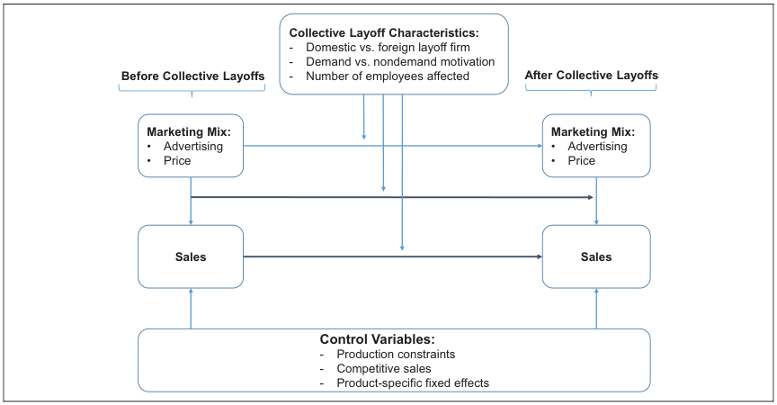

NOTE: figure/graphic rendered as an image from the PDF; its content is not machine-readable text. Caption (if any) follows as the next block.

**text found inside the figure**

**Marketing Mix:** • Advertising • Price

**Before Collective Layoffs After Collective Layoffs**

**Sales**

**Marketing Mix:** • Advertising • Price

**Sales**

**Control Variables:** - Production constraints - Competitive sales - Product-specific fixed effects

**Collective Layoff Characteristics:** - Domestic vs. foreign layoff firm - Demand vs. nondemand motivation - Number of employees affected

Figure 1. Conceptual framework.

126 Journal of Marketing 84(3)

Page 6

motivated by a decline in demand or by other reasons (e.g., collective layoffs driven by a supply-side search for efficiency gains; for examples, see Web Appendix A; Freeman and Cameron 1993),<sup>2</sup> and (3) the number of employees affected by the collective layoff.

We consider the empirical study of these collective layoff announcement characteristics as exploratory. Although there are clear reasons why these characteristics are expected to affect the commercial consequences of collective layoffs (as we elaborate subsequently), it is difficult to postulate the direction and magnitude of said effects ex ante.

Domestic versus foreign firms. Media sources typically provide richer coverage of domestic firms than of foreign firms, such that consumers are likely to be more informed about the former than about the latter. Therefore, consumers may experience less of an increase in uncertainty following a collective layoff announcement of a domestic firm than they would after an announcement of a foreign firm (Rinallo and Basuroy 2009). Consumers also perceive domestic firms as in-group actors and foreign firms as out-group actors (Crilly, Ni, and Jiang 2016) and, consequently, typically expect domestic firms to adhere to higher standards of fairness toward domestic workers than foreign firms (Mendoza, Lane, and Amodio 2014). Therefore, consumers may evaluate unfair behavior of domestic firms (as they are in-group members) more negatively than unfair behavior of foreign firms (as they are out-group members) (for a similar logic, see Valenzuela and Srivastava [2012]). Thus, for advertising elasticity we may expect that if it is a domestic firm (rather than a foreign firm) that lays off employees, the adverse effects of a collective layoff are stronger (i.e., due to lower increase in customer uncertainty [informative role] and higher decrease in likability and trustworthiness [persuasive role] compared with foreign firms). For sales and price elasticity, the effect of being a domestic, rather than foreign, firm depends on whether on average the smaller increase in customer uncertainty counteracts the greater decrease in likability and trustworthiness.

Collective layoff motive. When a firm indicates that a collective layoff is motivated by a decline in demand, it may create doubt in consumers’ minds regarding whether they will be able to continue their relationship with the firm in the future (Homburg, Klarmann, and Staritz 2012). Analysts and critics may magnify and further broadcast the “firm-in-decline” message and frame a perception of an uncertain future for the firm (Love and Kraatz 2009). Conversely, consumers may consider a decline in demand as a more justified reason for reducing manufacturing capacity than, for instance, the search for cost efficiency (i.e., the desire of the firm to increase profits). Most notably, delocalization of manufacturing to countries with

lower labor costs has been the source of hot societal debate and boycotts (Mojtehedzad 2019). Thus, the likeability and trustworthiness of a firm that announces a collective layoff as being motivated by a decline in demand may decrease less than those of a firm that does not present such motivations for its announcement (e.g., when the motive is the search for efficiency gains). Thus, for advertising elasticity we may expect that if decline in demand is mentioned as a motive for the collective layoffs (rather than another motive), the adverse effects of a collective layoff are weaker (i.e., due to greater increase in customer uncertainty [informative role] and smaller decrease in likability and trustworthiness [persuasive role] compared with nondecline motives). For sales and price elasticity, the effect of a demand-driven motive depends on whether, on average, the greater increase in uncertainty counteracts the smaller decrease in likability and trustworthiness, compared with other motives.

Number of employees. The number of employees being laid off is likely to be related to consumer awareness about, and the salience of, the collective layoff announcement (Homburg, Klarmann, and Staritz 2012). Thus, it is likely to moderate the extent to which the collective layoff announcement affects consumer uncertainty and the trustworthiness and likeability of the brand. We may expect that if more employees are laid off, the adverse effects of the layoff announcement on sales and price elasticity will be stronger. For advertising elasticity, the effect of the number of employees being laid off depends on whether, on average, the expected higher increase in uncertainty as more employees are laid off, counteracts the expected stronger decrease in likability and trustworthiness as more employees are laid off.

Control variables. In our empirical investigation we also control for other factors that may affect sales before and after the collective layoff announcement. In particular, to identify the magnitude of demand-side effects of a collective layoff announcement, our model must contain data on supply-side dynamics that may be affected by such collective layoffs. Thus, as noted previously, we control for production capacity constraints that may drive lower sales for the firm (Bresnahan and Ramey 1993), as reflected in production capacity utilization. We also control for competitive sales, which may affect ownfirm sales positively (i.e., capturing overall market trends) or negatively (i.e., capturing market-share stealing).

#### Empirical Study

In the automotive industry, our empirical context, collective layoffs, including plant closures, by major international manufacturers frequently occur both in the United States and in many Western European countries (Bailey et al. 2010). In North America, many manufacturing jobs have shifted from the United States to Mexico, which has experienced a massive investment in vehicle assembly in recent decades (Klier and Rubenstein 2011). In Europe, automotive assembly has shifted

2 Note that Palmon, Sun, and Tang (1997) use a comparable classification. They classify layoffs as supply-driven layoffs (also called “efficiency layoffs”), which are aimed at, or result from, improved efficiency, and demand-driven layoffs, which evolve from unfavorable market conditions.

Landsman and Stremersch 127

Page 7

from Western Europe to lower-wage Eastern European countries (Klier and Rubenstein 2011; Klier and Rubenstein 2015). In fact, automotive production in Poland, the Czech Republic, Hungary, and Slovakia reached a record high in 2015 with the production of 3.5 million units, making the region the secondlargest automotive hub in Europe, after Germany (The Economist Intelligence Unit 2016).

#### Data Collection

Fourth, for the countries, brands, and time periods we consider, we manually collected data on collective layoff announcements (n ¼ 205) in which a minimum of 90 employees were dismissed.<sup>4</sup> We began with an internet search for basic information on the factories that assemble cars of each of our brands. We then built for each brand a list of factories worldwide and noted the current status of each factory (open/closed/ sold), along with the year of closure or sale, when applicable. Next, we focused on the countries in our data and obtained detailed monthly information on factory closures (e.g., from press coverage). We carried out an additional search using each

factory’s name and a range of relevant dates to search for information on collective layoffs that did not involve plant closures. We then validated our data by cross-checking among different sources. Specifically, for the United States, we used a report issued by the Center for Automotive Research (Brugeman, Hill, and Cregger 2011) that provided details on closed (and repurposed) U.S. auto-manufacturing facilities. For Europe, we used the European Monitoring Center of Change database (Eurofound 2019). In addition, we used Automotive News Europe’s (2008) “Guide to Assembly Plants in Europe.” Finally, we used the brands’ own websites. We scanned their lists of existing factories to ensure that we had not missed any collective layoff announcement and used the “Media Centers” on their websites to obtain press releases on closure and dismissal announcements.

For every collective layoff announcement, we collected information on the announced motive for the collective layoff to code whether the layoffs were driven by a decline in demand (i.e., “demand-driven”) or not. We codeed collective layoff as demand-driven if a decline in demand was mentioned as a cause of the collective layoffs. We also coded whether the respective firm announcing the collective layoffs was domestic or foreign in the layoff country. In addition, we gathered the number of employees affected and the date (month and year) of the announcement.<sup>5</sup> To check data collection reliability, we employed two independent research assistants to gather the collective layoff announcement data. A third research assistant examined the joint list of announcements gathered by the first two to make sure there was full agreement across the two announcement lists and, in the case of a disagreement, gather the required information to resolve the inconsistency. The level of agreement between the first two research assistants before any disagreement resolution took place was high (95.6%).

#### Data Description

The 205 layoff announcements we analyze include 4 collective layoffs in Austria, 15 in Canada, 37 in France, 20 in Germany, 8 in Italy, 13 in Japan, 31 in Spain, 22 in the United Kingdom, and 55 in the United States. The investigated collective layoff announcements involved more than 300,000 employees. In summary, our empirical investigation utilizes 129,919 data points at the model-month-country level. Each data point captures sales,

3 For Japan and France, our data set covers the years 2000–2013. Our data set does not cover prices for Canada and Japan prior to 2007. Accordingly, we eliminate from our analysis collective layoff events that occurred during these periods and in these countries. 4 For each of the events, we also ensure that the brand’s models are also sold in at least one of the other sample countries where there is no other collective layoff announcement for that brand in the year before or after the event.

5 In the empirical tests presented in the following sections, we consider the month in which the collective layoff was announced as the time of “treatment” (rather than the month in which layoffs were expected to take effect). This choice is based on the fact that, at the point of announcement, consumers are exposed to information that may trigger mistrust and/or uncertainty. Moreover, in many cases, the actual layoff date was not clearly conveyed in the layoff announcements. Some indicated a general period within which the collective layoffs would take place (e.g., a coming year or two years), others did not mention the intended date at all, and still others announced effective dates that ultimately differed from the actual effective dates. In some cases, for instance, labor union negotiations or government interventions may shift the effective date of a layoff, impeding the capacity of outside analysts to identify this date, a task that becomes even more complicated across numerous events.

128 Journal of Marketing 84(3)

Page 8

advertising, pricing, and manufacturing information on a specific car model manufactured by a brand that announced a collective layoff in the 12-month period before or after the given month. In 118 announcements, a decline in demand was explicitly mentioned as a motive for the layoffs, and 105 of the collective layoffs were announced by domestic brands.

Table 2 presents descriptive statistics and a correlation matrix of our estimation data. Advertising spending, price, and competitive sales are all measured at the country-model-month level. We attribute corporate advertising spending (defined as advertising spending for the car brand that does not promote any specific car model) to the respective models, according to their relative model-level sales. Competitive car sales include all monthly sales for the respective country except those for the respective car model. For production capacity utilization, we first calculate for every plant of the brand the ratio between actual monthly production and maximum production capacity. Then, we calculate the production-weighted average of this ratio across all plants of the brand in a given region. This averaging is done for every month in our data to get the average monthly regional production capacity utilization for the brand.<sup>6</sup>

#### Model-Free Evidence

In this section, we examine sales, advertising, and price data before and after collective layoff announcements, without specifying a formal model. Such model-free evidence provides a first rough view on how these variables change following collective layoff announcements, albeit without the controls that we incorporate into our formal estimation (such as for endogeneity).

First, for each of the collective layoffs, we calculated the percentage change in the layoff brand’s unit sales in the layoff

Panels A and B of Figure 2 present the distribution of percent change in sales for different collective layoff characteristics. Panel A compares the distributions for domestic and foreign collective layoff firms. We observe that, on average, collective layoffs of domestic firms are associated with a sales decrease of 5.5%, whereas layoffs for foreign firms are associated with a sales decrease of 7.7%. Panel B compares the distributions for demand-driven and non-demand-driven collective layoff announcements. We find that, on average, collective layoffs that are announced as demand-driven are associated with a decrease in sales of 7.1%, whereas layoffs that are non-demand-driven are associated with a decrease in sales of 5.8%.

Second, we calculated the percentage change in the layoff brand’s advertising spending in the layoff country, comparing postannouncement levels with preannouncement levels. We find that the median change in advertising spending is 2%, suggesting that firms do not show a dominant tendency to

Table 2. Descriptive Statistics and Correlation Matrix (for Model Estimation).

[output not shown]

NOTE: table converted from PDF layout to HTML text; cell boundaries are reconstructed. See PDF if exact alignment matters.

*p < .05. **p < .01. aExpenditures in Euros for the car model. bCar model price in Euros. cUnit sales (at car-model level) refers to the monthly unit sales of a car model. Competitive sales refer to the sum of unit sales across all other models of all brands. Notes: The descriptive statistics and correlation matrix are based on the data we use for model estimation (i.e., the data correspond only to the 12-month periods before and 12-month periods after all layoff announcements in the relevant countries for each collective layoff and across the respective car models for the brand). In total, we use 129,919 data points for model estimation.

6 We use the term “region” to describe the production area to which a given country belongs and in which its supply of cars is likely to be produced. The regions are based on the definition of our production data provider, HIS, and consist of Europe, North America, and Japan/Korea.

7 Percent change is calculated as postevent mean monthly levels over a period of 12 months, minus pre-event mean levels over a period of 12 months, divided by pre-event mean levels for the brand.

Landsman and Stremersch 129

Page 9

substantially increase or decrease spending in the year following a layoff announcement.<sup>8</sup> Panels A and B of Figure 3 present the distributions of percent change in advertising spending for domestic and foreign collective layoff firms (Panel A), and for demand-driven and non-demand-driven collective layoffs (Panel B). We observe that a higher percentage of domestic firms, compared with foreign firms, increased advertising spending by up to 20% following a layoff announcement; yet a higher proportion of foreign firms than domestic firms increased advertising spending by more than 40% in the year following the layoff announcement. Similarly, when comparing demand-driven and non-demand-driven layoff announcements, we observe that non-demand-driven announcements were more likely than demand-driven announcements to be followed by an increase in advertising spending of up to 20%,

whereas demand-driven announcements were more likely than non-demand-driven announcements to be followed by an increase in advertising spending of more than 40%.

#### A DID Model for Sales, Advertising, and Pricing

Our econometric model should address three main challenges. First, the collective layoffs are not random events but are decisions that may be driven by expected demand fluctuations. This concern is especially relevant when a drop in demand is given

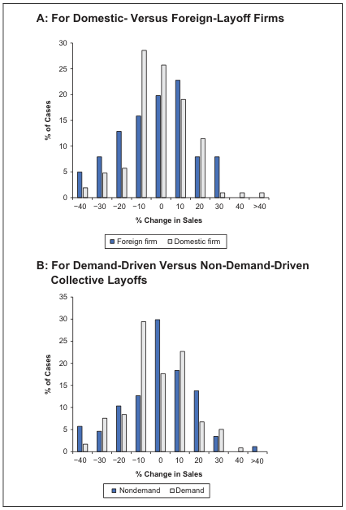

NOTE: figure/graphic rendered as an image from the PDF; its content is not machine-readable text. Caption (if any) follows as the next block.

**text found inside the figure**

**A: For Domestic- Versus Foreign-Layoff Firms**

**B: For Demand-Driven Versus Non-Demand-Driven**

**Collective Layoffs**

0

5

10

15

20

25

30

−40 −30 −20 −10 0 10 20 30 40 >40

**% of Cases**

**% Change in Sales**

Foreign firm Domestic firm

0

5

10

15

20

25

30

35

−40 −30 −20 −10 0 10 20 30 40 >40

**% of Cases**

**% Change in Sales**

Nondemand Demand

Figure 2. Percentage change in sales. Notes: Percentage change is calculated as postevent mean monthly levels over a period of 12 months, minus pre-event mean levels over a period of 12 months, divided by pre-event mean levels for the brand.

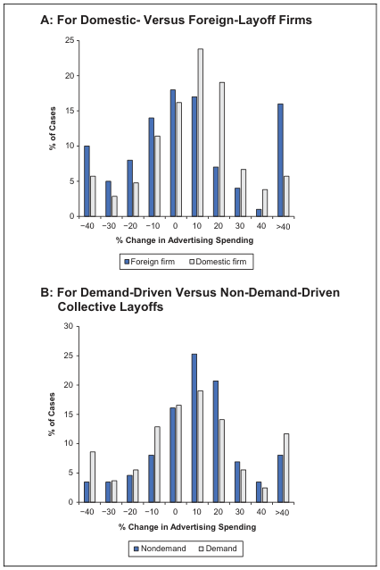

NOTE: figure/graphic rendered as an image from the PDF; its content is not machine-readable text. Caption (if any) follows as the next block.

**text found inside the figure**

**A: For Domestic- Versus Foreign-Layoff Firms**

**B: For Demand-Driven Versus Non-Demand-Driven Collective Layoffs**

0

5

10

15

20

25

−40 −30 −20 −10 0 10 20 30 40 >40

**% of Cases**

**% Change in Advertising Spending**

Foreign firm Domestic firm

0

5

10

15

20

25

30

−40 −30 −20 −10 0 10 20 30 40 >40

**% of Cases**

**% Change in Advertising Spending**

Nondemand Demand

Figure 3. Percentage change in ad spending. Notes: Percentage change is calculated as postevent mean monthly levels over a period of 12 months, minus pre-event mean levels over a period of 12 months, divided by pre-event mean levels for the brand.

8 Because of the high variance in the percentage change in advertising spending, we find it more informative to present the median and not the mean across the collective layoff events we investigate.

130 Journal of Marketing 84(3)

Page 10

as a motive for the collective layoffs. Second, advertising and pricing are strategic decision variables, which are driven by sales objectives and expectations. Third, unobservable shocks may simultaneously affect sales, advertising spending, and prices.

To address these challenges, we develop a hierarchical Bayesian model consisting of three dependent variables: sales, advertising, and price. Accordingly, our model comprises a system of three equations. To address the first form of endogeneity (nonrandomness of collective layoff announcements), our model adopts a DID approach. In our data, we observe sales before and after collective layoff announcements in a “treatment” country (the treatment being the collective layoff announcement for a given brand in a given country), which we can compare with “control” countries (i.e., all countries other than the treatment country in our data set in which we do not observe a collective layoff announcement for that brand in the 12 months before or after the focal collective layoff announcement).

The appropriateness of this DID approach is contingent on two key assumptions that seem to be realistic in our context. First, we assume that the collective layoff decision is taken at the regional, and perhaps even global, production level, and not in the layoff country in isolation; thus, the treatment is not driven solely by the demand conditions in the treatment country. Second, we assume that the impact of collective layoff announcements on consumer demand is country-specific. Typically, media outlets cover layoff announcements in their own country more intensively than they cover announcements of collective layoffs abroad. Consumers are more likely to be aware of such announcements in their own country than in other countries and to consider workers in their own country as in-group members, compared with workers abroad.

To ease the interpretation of our DID model, we compare a simulated “but-for” world—the world that would have existed had a collective layoff announcement never occurred—to the “actual” world—the world that exists given that the collective layoff has occurred. We adopt this method from the legal and economics literature (Hastings and Williams 2016); it has also been used previously in marketing (Mahajan, Sharma, and Buzzell 1993).

Figure 4 presents a stylized example. A line represents the (stylized) actual sales of the BMW 3 Series in a collective layoff country (in this case, the United States) and a bold line represents the (stylized) actual sales of the BMW 3 Series in a control country (in this case, Germany). At T*, BMW announces a collective layoff in the United States. The “actual” world comprises the observed sales of the BMW 3 Series in the United States after T*, while the “but-for” world (depicted by a dashed line) comprises the expected sales of the BMW 3 Series in the United States, absent a collective layoff announcement of BMW in the United States, based on the evolution of the sales of the BMW 3 Series in the United States before T* and on the sales of the BMW 3 Series in Germany before and after T*. The difference between the “actual” sales levels in the United States after T* (i.e., the full line) and the “but-for” sales levels in the United States after T* (i.e., the dashed line) is the DID.

To address endogeneity in pricing and advertising spending, we use an instrumental-variable procedure (Rossi, Allenby, and McCulloch 2005). We utilize the periodic price and advertising spending for the car model, averaged across the control countries, as instrumental variables for the periodic price and advertising spending of a given car model (see the exact specification next). These variables are correlated with pricing and advertising for the car model in the layoff country, because they may

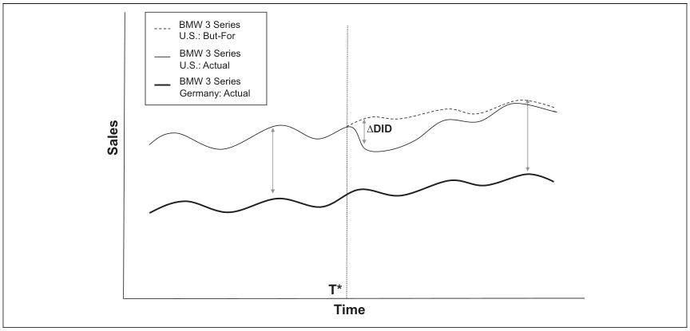

NOTE: figure/graphic rendered as an image from the PDF; its content is not machine-readable text. Caption (if any) follows as the next block.

**text found inside the figure**

∆**DID**

BMW 3 Series U.S.: But-For

BMW 3 Series U.S.: Actual

BMW 3 Series Germany: Actual

**Sales**

**Time T***

Figure 4. Stylized example for sales of BMW 3 Series before and after a collective layoff event for BMW in the United States.

Landsman and Stremersch 131

Page 11

capture the temporal global marketing strategy and cost function for that car model over time, as well as the temporal cost of advertising. However, these variables are not expected to be correlated with that model’s unit sales in the layoff country, because potential buyers in that country are not likely to be exposed to prices and advertising in other countries. Finally, we allow for correlation in unobserved temporal shocks of the three dependent variables, by specifying the errors of the three equations in our system to be jointly distributed.

#### Model Specification

We start with the specification of Model 1, which focuses on the main effects of collective layoff announcements on sales, advertising elasticity, and price elasticity in the collective layoff country. We then proceed to Model 2, which further explores the role of our moderators in these main effects.

The dependent variable in the first equation of Model 1 is the log-transformed unit sales of car model m of brand j in country c at month t (lnSalesmjct), as follows:

We log-transformed all the independent variables such that the respective parameters denote the elasticities of the corresponding variables. Advmjct represents the level of advertising spending for car model m at time t in country c. Pricemjct represents the price of car model m at time t in country c. Accordingly, b<sup>Sales</sup>

1 jct <sup>and</sup> <sup>b</sup><sup>Sales</sup> 2 jct <sup>represent</sup> <sup>advertising</sup> <sup>and</sup> <sup>price</sup> elasticities. As our theoretical expectations regarding advertising and price elasticities are at the brand-country level, we specify these random parameters at the brand-country-time level.

Similarly, b<sup>Sales</sup>

0 jct <sup>represents</sup> <sup>the</sup> <sup>baseline</sup> <sup>sales</sup> <sup>for</sup> <sup>brand</sup> <sup>j</sup> <sup>in</sup> country c at time t, after controlling for the marketing mix and other market conditions (Van Heerde, Helsen, and Dekimpe 2007). The inclusion of base sales allows us to obtain unbiased estimates for advertising and price elasticities. Our model also accounts for past advertising spillovers through the inclusion of lagged advertising levels, captured by g<sup>Sales</sup>

2 lm <sup>.</sup> <sup>We</sup> <sup>utilize</sup> <sup>a</sup> <sup>grid</sup> search for the number of lags. CompSalesmct represents competitive car unit sales in country c at time t. d<sup>Sales</sup>

0 t and g<sup>Sales</sup>

0 m <sup>in</sup> Equation 1 are random time and car model effects, respectively. The parameters g<sup>Sales</sup>

02 m <sup>and</sup> <sup>d</sup><sup>Sales</sup> 0 t are each drawn from a normal distribution.

Following the principles of a DID model, our focal interest is in whether time t is before or after the collective layoff announcement, and whether country c is the treatment or a control country. Accordingly, we specify the baseline sales,

as well as the advertising and price elasticity parameters (b<sup>Sales</sup>

0 jct <sup>,</sup> <sup>b</sup><sup>Sales</sup> 1 jct <sup>,</sup> <sup>and</sup><sup>b</sup><sup>Sales</sup> 2 jct <sup>, respectively),</sup> <sup>as</sup> <sup>follows:</sup>

Post jct is a vector of dummy variables that indicate whether time t is before (12 months) or after (12 months) a collective layoff announcement of brand j in country c. CLCountryjct is a dummy variable indicating whether c is a collective layoff country, in which case the variable is equal to 1 in the periods surrounding the layoff announcement (from 12 months before until 12 months after) and 0 otherwise. To clarify, assume that Mazda has made a collective layoff announcement in Germany in March 2012. For all Mazda car models, Postjct is 0 for all time periods before March 2012 and 1 for time periods from March 2012 to February 2013. CLCountryjct is equal to 1 for all Mazda car models in Germany between March 2011 and February 2013, and equal to 0 otherwise. Thus, for the collective layoff announcement in question (and, similarly, for any collective layoff announcement) we might see Post/CLCountry combinations of 0/0 (e.g., Austria before the announcement [i.e., between March 2011 and February 2012), 0/1 (Germany before the announcement [i.e., between March 2011 and February 2012), 1/0 (e.g., Austria after the announcement [i.e., between March 2012 and February 2013), and 1/1 (Germany after the announcement [i.e., between March 2012 and February 2013).<sup>9</sup>

PCUjct in Equation 2 is the production-weighted average production capacity utilization of brand j at month t in the region corresponding to country c. The error terms u<sup>Sales</sup>

k; jct <sup>are assumed to</sup>

be uncorrelated with e<sup>Sales</sup>

mjct <sup>and</sup> <sup>jointly</sup> <sup>distributed</sup> <sup>as</sup> u<sup>Sales</sup>

Next, we further specify an advertising equation and a price equation in our system (Rossi, Allenby, and McCulloch 2005). We specify the advertising equation as follows:

The instrumental variable for car model advertising is Advmjc<sup>0</sup>t, which is calculated as the level of advertising spending for model m at time t, averaged across all countries in which there was no collective layoff announcement for brand

9 Web Appendix B contains a description of how we stacked the DID variables for the estimation of our model using a stylized example.

j in the 12 months preceding or following the collective layoff announcement.<sup>10</sup>

0 jct <sup>in</sup> <sup>Equation</sup> <sup>3 represents</sup> <sup>baseline</sup> <sup>advertising</sup> <sup>levels</sup> <sup>at</sup> the brand-country-time level. We allow for the possible influence of the collective layoff announcement and its characteristics on base advertising by specifying this intercept as follows:

ð4Þ All variables in Equation 4 are defined as previously. The error term u<sup>Adv</sup>

jct <sup>is</sup> <sup>assumed</sup> <sup>to</sup> <sup>be</sup> <sup>uncorrelated</sup> <sup>with</sup> <sup>e</sup><sup>Adv</sup>

mjct <sup>and</sup> distributed as N 0; z<sup>2</sup>

. We specify the price equation in our system as follows:

The instrumental variable for car model price is Pricemjc<sup>0</sup>t, which is calculated as the price of car model m at time t, averaged across all countries where there was no collective layoff announcement for brand j in the 12 months preceding or following the layoff announcement.<sup>11</sup>

b<sup>Price</sup>

0 jct <sup>in</sup> <sup>Equation</sup> <sup>5</sup> <sup>represents</sup> <sup>the</sup> <sup>baseline</sup> <sup>price</sup> <sup>at</sup> <sup>the</sup> brand-country-time level. Similarly to what we did in the sales and advertising equations and for similar reasons, we specify this intercept as follows:

All variables in Equation 6 are defined as previously. The error termu<sup>Price</sup>

as N 0; z<sup>2</sup>

. The parameters g<sup>Adv</sup>

03 m<sup>,</sup><sup>g</sup><sup>Price</sup> 03 m<sup>,</sup><sup>d</sup><sup>Adv</sup> 0 t <sup>and</sup><sup>d</sup><sup>Price</sup> 0 t are each drawn from a normal distribution. We model the errors of Equations 1, 3, and 5 to be jointly distributed as e<sup>Sales</sup>

#### Exploring the Moderating Role of Collective Layoff Characteristics

Domesticjct in Equation 7 is a dummy variable that equals 1 if brand j is a domestic brand in the collective layoff country, and 0 otherwise. MotiveDjct is a dummy variable that equals 1 if the layoff is driven by a decline in demand and 0 otherwise. Employeesjct is the announced number of employees to be laid off. This variable is positive in the 12 months following the layoff announcement, and 0 otherwise.<sup>12</sup>

#### Estimation Results

We jointly estimated the sales, advertising, and price equations of Model 1 using a hierarchical Bayesian estimation technique. We ran the algorithm for 5,000 iterations. The first 4,000 iterations were used for burn-in, and every tenth iteration of the last 1,000 was saved to obtain the posterior parameter estimates. We graphically plotted these estimates to examine their convergence (plots are available on request). Table 3 presents the

10 Because scales of advertising spending levels may vary greatly across countries with different population sizes, for the construction of this variable we first standardize advertising spending at the country level for each car model and then take the monthly average across the relevant countries (i.e., across all control countries). 11 For price, the independent variable distribution is very similar to that reported in Table 2 (M ¼ 28,007, SD ¼ 16,849). For advertising, because the independent variable is constructed by first standardizing advertising at the country and car-model level over the 15-year period we consider, the distribution is somewhat different from that of our advertising variable (M ¼ 126.10, SD ¼ 14,645).

12 Because this variable is specified as zero in all pre-event months, in Equation 7 we do not include all interaction terms between Employeesjct and Postjct.

estimation results of the second-layer parameters of b<sup>Sales</sup>

0 jct <sup>,</sup><sup>b</sup><sup>Sales</sup> 1 jct <sup>,</sup><sup>b</sup><sup>Sales</sup> 2 jct <sup>,</sup><sup>b</sup><sup>Adv</sup> 0 jct<sup>,</sup> <sup>and</sup><sup>b</sup><sup>Price</sup> 0 jct <sup>.</sup> In this article, we focus on the effect of collective layoff announcements on sales, advertising elasticity, and price elasticity. For sales, the effect of such announcements is composed, in part, of their potential effect on marketing-mix variables and marketing-mix elasticities. For this reason, we cannot assess the effect of collective layoffs solely on the bases of changes in the intercept of the sales equation. Therefore, we start by reviewing the estimation results for the effect of collective layoffs on marketing-mix elasticities. That is, the interaction effects between a postannouncement period and the layoff country, y1,3 and y2,3, in the second-layer equations of the two elasticity parameters b<sup>Sales</sup>

1 jct and b<sup>Sales</sup>

2 jct <sup>(see Equation 2 and col</sup>umns 4 and 5 in Table 3). Subsequently, we simulate the overall effect of collective layoffs on sales on the basis of a comparison of “but-for” and “actual’ sales.

We find that these DID interaction parameters are negative and significant in both the advertising elasticity and the price elasticity equations, indicating that both elasticities are lower following a collective layoff announcement than absent the announcement ( y<sup>Sales</sup>

1;3 ¼ .02; y<sup>Sales</sup>

2;3 ¼ .11). These significant changes in advertising and price elasticities represent a 9.8% drop in advertising elasticity, and a 19.2% drop in price elasticity.

While these findings show that more than 95% of the posterior distribution of each of the DID interaction parameters is negative both for advertising elasticity and for price elasticity, we observe substantial variance in both parameter distributions. Next, we investigate the moderating role of the collective layoff communication characteristics in the effects of the DID interaction parameters.

#### The Role of Collective Layoff Characteristics

Table 4 presents the estimation results of Model 2. We focus on the estimated interaction parameters between a postannouncement period, a collective layoff country, and the announcement characteristics, for advertising elasticity and price elasticity,

y1,12, y2,12, y1,13, y2,13, y1,14 and y2,14 (see columns 4 and 5 in Table 4).

We find that a collective layoff announcement of a domestic firm is associated with lower postlayoff advertising and price elasticity than a collective layoff announcement of a foreign firm ( y<sup>Sales</sup>

1;12 <sup>¼</sup> <sup>.07;</sup> <sup>y</sup><sup>Sales</sup> 2;12 <sup>¼</sup> <sup>.16).</sup> <sup>The</sup> <sup>stronger</sup> <sup>decrease</sup> <sup>in</sup> advertising elasticity for domestic firms than for foreign firms is as expected. The stronger decrease in price elasticity for domestic firms, is in line with the expectation that domestic firms experience a greater decrease in likability and trustworthiness than foreign firms following collective layoff announcements.

For layoff motive, we find that a collective layoff announcement that is demand-driven is associated with lower postlayoff price elasticities (a less negative elasticity) than a non-demanddriven announcement ( y<sup>Sales</sup>

2;13 <sup>¼</sup><sup>.12). This finding is in line with</sup> the expectation that, following demand-driven layoff announcements, firms experience a smaller decrease in likability and trustworthiness than following collective layoff announcements that mention other motives.

For the announced number of affected employees, we find that a collective layoff announcement that involves more employees is associated with higher postlayoff advertising elasticities than a collective layoff announcement that involves fewer employees ( y<sup>Sales</sup>

1;14 <sup>¼</sup><sup>.01). This finding is consistent with</sup> the expected higher consumer uncertainty following collective layoff announcement the more employees that are laid off as well as the increased informative role of advertising in such situations.

#### Collective Layoff Announcements, Advertising Spending, and Prices

To examine the effect of a collective layoff announcement on advertising spending and prices, we elaborate on the estimation results of Model 2, which incorporates all moderators. Columns 6 and 7 in Table 4 present the (Model 2) estimation results of the second-layer parameters of base advertising spending and base prices (b<sup>Adv</sup>

0 jct <sup>and</sup> <sup>b</sup><sup>Price</sup> 0 jct <sup>).</sup> <sup>These</sup> <sup>results</sup>

Table 3. Estimation Results of Second-Layer Equations, Model 1.

[output not shown]

NOTE: table converted from PDF layout to HTML text; cell boundaries are reconstructed. See PDF if exact alignment matters.

Notes: Boldfaced parameters indicate that 95% of the posterior distribution is above/below zero. The estimation is based on 129,919 observations.

indicate that advertising spending is lower after a collective layoff announcement of a domestic brand than after a collective layoff announcement of a foreign brand ( y<sup>Adv</sup>

0;12 <sup>¼</sup> <sup>.27).</sup> <sup>The</sup> effect of a collective layoff announcement on car prices, however, does not seem to differ across announcements with different characteristics.

#### Marginal Effects of Collective Layoff Announcements on Advertising and Price Elasticities

The marginal effects of collective layoff announcements are captured by the second-layer parameters of each elasticity corresponding to a postannouncement period in a collective layoff country (see Equation 7). These marginal effects on b<sup>Sales</sup>

1 jct <sup>and</sup> b<sup>Sales</sup>

2 jct <sup>are</sup> <sup>calculated</sup> <sup>as</sup> <sup>follows:</sup>

Subscript q takes the value of 1 if it refers to advertising elasticity ðb<sup>Sales</sup>

1 jct <sup>Þ</sup><sup>, and 2 if it refers to price elasticity (</sup><sup>b</sup><sup>Sales</sup> 2 jct <sup>). To</sup> account for layoff characteristics, we plug in Equation 8 all possible value combinations of Domesticjct and MotiveDjct. For layoff size, we utilize the mean number of employees across all layoff announcements we analyze. In line with the Bayesian estimation approach, the calculation must account for parameter uncertainty. We thus utilize all draws from the posterior distributions of the parameters in Equation 8 to calculate posterior draws of the marginal effects.

Table 5 presents the posterior means of the marginal effects on advertising elasticity and price elasticity, across possible values of the layoff announcement characteristics we examine, based on the estimates of Model 2. We find a significant decrease in advertising elasticity only following layoff announcements by domestic firms. We find a significant negative change in price elasticity (i.e., a more negative price elasticity) following all announcement types, with the exception of a collective layoff announcement of a foreign firm that is presented as being demand-driven. We further see that the largest mean marginal change in price elasticity is

Table 4. Estimation Results of Second-Layer Equations, Model 2.

[output not shown]

NOTE: table converted from PDF layout to HTML text; cell boundaries are reconstructed. See PDF if exact alignment matters.

Notes: Boldfaced parameters indicate that 95% of the posterior distribution is above/below zero. The estimation is based on 129,919 observations.

expected for non-demand-driven layoff announcements of domestic firms.

#### Other Effects

Table 6 presents the results of the estimations of the car-modellevel parameters in Equations 1, 3, and 5. We find that competitive sales and lagged advertising have positive effects on unit sales ( g<sup>Sales</sup>

1 m <sup>¼</sup><sup>.68,</sup><sup>g</sup><sup>Sales</sup> 2;1 m <sup>¼</sup><sup>.16) and on advertising spend</sup>ing (g<sup>Adv</sup>

1 m <sup>¼</sup> <sup>.17;</sup> <sup>g</sup><sup>Adv</sup> 2;1 m <sup>¼</sup> <sup>.60).</sup> <sup>Competitive</sup> <sup>sales</sup> <sup>also</sup> <sup>have</sup> <sup>a</sup> significant negative effect on prices (g<sup>Price</sup>

1 m ¼ .04). We also find that both instrumental variables have significant positive effects on advertising spending and car price (g<sup>Adv</sup>

3 mj <sup>¼</sup> <sup>.23,</sup> g<sup>Price</sup>

#### “Actual” to “But-For” Comparisons Across Announcement Types

Next, we examine the economic significance of our statistical findings, using the “but-for” analysis we introduced previously.<sup>13</sup> For this calculation, “actual” sales are the observed

sales in our data. “But-for” sales (BFSales mjct) are the corresponding predicted sales, based on our estimation results, had the collective layoff announcement not occurred. We calculate these predicted values, ln BFSales mjct, as follows:

Eq pre; qjct <sup>are</sup> <sup>the</sup> <sup>mean</sup> <sup>time-varying</sup> <sup>brand-level</sup> <sup>para</sup>meter estimates in prelayoff periods. These parameters replace the periodic postannouncement first-level parameters to simulate the “but-for” condition<sup>14</sup> and are specified as follows:

ð10Þ BFAdv mjct and BFPrice mjct in Equation 9 are predicted after the layoff announcement “but-for” values for advertising and price, respectively, which are calculated as follows:

Table 6. Estimation Results: Car-Model-Level Parameters.

[output not shown]

NOTE: table converted from PDF layout to HTML text; cell boundaries are reconstructed. See PDF if exact alignment matters.

Notes: Boldfaced parameters indicate that 95% of the posterior distribution is above/below zero. For car model effects presented in this table, we report the hyperparameter (i.e., the means across car models).

Table 5. Mean Change in Advertising Elasticity and Price Elasticity.

[output not shown]

NOTE: table converted from PDF layout to HTML text; cell boundaries are reconstructed. See PDF if exact alignment matters.

Notes: n.s. ¼ not significant. Boldfaced parameters indicate that 95% of the posterior distribution is above/below zero.

13 While some scholars view “but-for” causation as a special case of counterfactual analysis used to compare real-world outcomes with those in a world in which a harmful action has not happened (Pearl 2009; Spellman, and Kincannon 2001), others distinguish between counterfactual and potential outcome causation and “but-for” causation (Cox, Popken, and Sun 2018). According to Cox, Popken, and Sun (2018), in a typical counterfactual and potential outcome causation test, modeling assumptions derive a hypothetical world in which there is one unit less of some cause variable leading to a certain difference in an outcome variable. The logic behind a “but-for” causation claim is that a cause (collective layoffs in our case) creates a response that would otherwise not have occurred. Such causation can be claimed as long as other

conditions are controlled for in the empirical investigation so that the mere cause suffices to create the response. A DID approach is a suitable empirical setting for the investigation of such causation type. 14 The prelayoff parameters are used here as a proxy for “but-for” postlayoff parameters. The true “but-for” parameters also account for changes in postlayoff parameters in the control condition.

The values of all other parameters in Equations 9 to 12 are the estimated values of Model 1 parameters (see Table 3). The error terms, ^e<sup>Sales</sup>

where <sup>^</sup>S e is the estimated variance–covariance matrix of the error terms of our three model equations. In line with our Bayesian estimation approach, the calculation of “but-for” values must account for parameter uncertainty. We thus calculate probabilistic “but-for” values using all estimated draws from the parameters’ posterior distributions.

We compare the “actual” and “but-for” values for sales, advertising, and prices and calculate the percentage change between the actual, observed values and the calculated, “butfor” values for every postlayoff announcement period in our sample. We average these changes for each collective layoff announcement, across all the car models for the respective brand.

“Actual” to “but-for” sales comparisons. The mean percentage change between “actual” and “but-for” sales across our collective layoff announcements is 8.7%. This indicates that, on average, for the brands in our sample, sales are 8.7% lower in the year following the announcement than their expected level absent the announcement. This drop in sales is somewhat larger than the actual drop of 6.6% that we observed in the model-free section. Across announcements with different characteristics, we find that the mean percentage change between “actual” and “but-for” sales is 8.8%, 8.7%, 7.9%, and 9.9%, for announcements of domestic firms, announcements of foreign firms, demand-driven announcements, and non-demand-driven announcements, respectively.

“Actual” to “but-for” comparisons for advertising and prices. To investigate whether and how firms make changes in advertising spending and pricing after issuing collective layoff announcements, we also calculate the percentage change between “actual” and “but-for” advertising spending and price levels

(see Equations 11 and 12). For advertising spending, we find that the mean percentage change between “actual” and “butfor” spending across the layoff announcements in our data set is 16%.<sup>15</sup> In fact, for 84% of the layoff announcements, we find that actual advertising for the brand is lower than the predicted “but-for” value. These findings indicate that many firms spend less on advertising in the year following collective layoff announcements than they would have been expected to spend absent the announcements.

For pricing, our estimates suggest that the difference between “actual” and “but-for” prices is very low. The mean percentage difference is 1%, indicating that firms do not seem to change their pricing strategy following collective layoff announcements.

We further separately calculated the percentage change compared to the “but-for” scenario due to the lower marketing-mix elasticities, keeping the actual (observed) advertising and pricing levels. We find that the mean drop in sales due to the change in elasticities is 5.1% compared with “but-for” sales. This finding indicates that the elasticity component is responsible, on average, for 58% of the predicted change in sales due to the collective layoff announcement.

#### Robustness

To examine the robustness of our findings, we estimated three simple models based on our full model: an ordinary least squares regression for sales; a seemingly unrelated regression model with sales, advertising, and price as dependent variables; and a two-stage least-squares model for sales, where advertising and price are treated as endogenous. While such models have certain limitations—such as the fact that they do not address heterogeneity or endogeneity—they may still provide a sanity check of our DID approach. We compared the estimates obtained with these models (i.e., the main effects of collective layoff announcements on advertising and price elasticities that we obtain as well as the moderating effects of the three layoff characteristics on these main effects) with the estimates of our main model (see Web Appendix C). In total, we corroborated the face validity of eight coefficients (main DID effect and three moderating effects on that main effect, for each elasticity). For advertising elasticity, we find all coefficients to be robust across all estimation methodologies. For price elasticity, two out of four coefficients identified in the main model are not replicated with the alternate simpler models. We therefore recommend that readers interpret our price elasticity findings with more caution than our advertising elasticity findings.

We carried out several additional robustness checks to further test the validity of our results. First, we estimated a model that takes into account the global (instead of regional) average production capacity utilization for the brand. We also checked

15 Due to the high variance in the “actual” to “but-for” comparisons in advertising spending, for the calculation of average changes across the collective layoff announcements we investigate, we replace all values greater than a 300% increase (13 cases) by a fixed value of 300%.

the production capacity utilization in the plants corresponding to the collective layoff announcements in our sample. For 6 of the 205 announcements, we found that the production capacity utilization of the plant in the year following the announcement was greater than 90%.<sup>16</sup> We estimated our model excluding these six announcements and found all our results to be robust.

Second, we examined the types of laid-off employees. We found that 172 announcements mentioned production workers, 8 mentioned research-and-development (or design) workers, 23 mentioned “headquarters” workers (e.g., management, marketing, sales, finance), and 15 provided no information regarding the types of employees involved. Note that more than one type of employee could be mentioned in a single layoff announcement. These data suggest that although it is common in the automotive industry for production workers to be affected by collective layoffs, other employees might also be involved in such layoffs. As a robustness check, we estimated the model using only events that mention production workers as the type of employee to be laid off and found the same effects.

Third, we varied the total observation window for a collective layoff between 18 months (6 months before and 12 months after the announcement) and 24 months (12 months before and 12 months after the announcement). Again, we found our results to be robust. In summary, our main results show high robustness over all these alternative model specifications (estimation results of these models appear in Web Appendix C).

#### Implications

This article examines the commercial consequences of collective layoff announcements using data on 205 collective layoff announcements that affected more than 300,000 employees. It offers several implications for managers whose firms are considering initiating collective layoffs or are experiencing the commercial consequences of such layoffs, and for market analysts studying collective layoff announcements and their consequences.

Collective layoffs are likely to entail negative demand consequences for the firms that initiate them. We observed that the majority of brands in our data set that issued collective layoff announcements (two out of three) faced a drop in sales, in absolute terms, in the layoff country during the year following the announcement. Using our model estimates, we showed that, on average, sales following collective layoff announcements are 8.7% lower than their expected level absent the announcements. These changes result, in part, from lower advertising elasticity, potentially higher price sensitivity, and lower advertising spending following the layoff announcements. Given these robust findings, we suggest that firms should go beyond supply considerations when they consider downsizing and integrate consumers’ response in their decision calculus.

Specifically, firms should include marketers in the task forces that manage collective layoffs, beyond functional representatives of other areas, such as operations and finance.

Our findings also provide essential insights to marketers as they ponder whether the marketing instruments they have at their disposal (e.g., advertising, price) may dampen adverse demand effects. We find that advertising elasticity and price elasticity typically decrease following layoff announcements. At the same time, we also find that firms, on average, spend less on advertising in the layoff country following layoff announcements than they would absent the announcements. Given the lower advertising elasticity following collective layoff announcements, it seems likely that decreasing or even merely sustaining advertising spending in the layoff country will lead to lower sales in that country and a loss of market share. Lowering advertising spending as a response to a decrease in advertising elasticity may be considered the optimal solution to a marketing-mix allocation problem (Nichols 2013). However, to counteract a negative demand spiral following collective layoff announcements, marketers might consider increasing their investment in advertising in the respective country following the layoff announcement, as long as advertising elasticity remains positive, to correct for lower advertising elasticity. Layoff firms could also consider such a temporary increase in advertising spending as a restructuring cost.

For pricing, we propose that increased price sensitivity cannot universally form a basis for price cuts to support brand share in the affected country. Of course, other reasons may exist for temporary price cuts in the respective country. We do recognize that this article is only a first attempt at addressing this question and that future research is needed to provide more guidance on pricing implications.

Beyond the implications of our results for managers, the analytical framework we have developed is also relevant for internal analysts who study the impact of collective layoffs. The heterogeneity we observed in consumer response suggests that analysts should carefully tailor the sample and variables to suit the specific context that they wish to investigate, in terms of the type of firm that is affected, or the reason for the collective layoff, given the heterogeneity in consumer response we have found. On such a tailored sample, marketing analysts could then utilize our model framework and retrieve simulation results for different scenarios (considering, for instance, different advertising spending levels). As with any prediction tool that deals with a market shock, one should not expect total accuracy; nevertheless, we suggest that such a tool can stimulate important discussions in management teams on the commercial consequences of collective layoffs. From our discussions with practitioners who have been involved in such collective layoff decisions (including representatives of two companies whose brands are included in our data set, i.e., Volkswagen and General Motors), we have learned that decision makers primarily tend to take manufacturing efficiency considerations into account while generally ignoring potential demand consequences. The tools proposed herein have the

16 The mean production capability utilization in our data is .71 (see Table 2). In only 9% of our observations the production capability utilization is higher than 90%.

potential to help marketers in downsizing firms to draw more attention to demand consequences.

Our work can also prove useful to external business analysts. The media often ask such external experts to predict the consequences of collective layoffs on the layoff brand or on its consumers. Similarly, our results could be informative for economists trying to predict broader economic impacts of layoffs. From our findings, three conclusions are worth keeping in mind. First, a negative impact on sales is more likely than no impact at all. Second, the impact on sales is likely to be rather large (8.7%, on average). Third, the exact magnitude of this effect depends on the characteristics of the announcements. Analysts can code the collective layoff announcement on the characteristics that we have analyzed and make inferences from our results regarding whether the impact of the collective layoff on demand will be more or less severe than the average.

#### Limitations and Directions for Further Research

Third, drawing from prior theory, we were able to identify mechanisms that might underlie consumers’ responses to collective layoffs and to firms’ marketing-mix decisions in the wake of such layoffs; however, our (secondary, behavioral) data did not enable us to prove that these mechanisms were indeed at play. It would be interesting to explore and prove such mediation mechanisms, potentially utilizing primary data collected before and after collective layoffs are announced. Online chatter that takes place before and after a layoff announcement would be a useful source of such data.

Fourth, our study constitutes a first exploratory step in elucidating the role of announcement characteristics in the commercial consequences of collective layoffs, examining three characteristics of interest. Future research should focus on the multitudes of additional communication characteristics that are likely to be worthy of study. For example, it would be interesting to examine the extent to which a firm’s presence on social media or the sentiment of the news coverage about a collective layoff affect its commercial consequences. Such investigations could also offer a tighter connection with the mediation mechanism than the current study offers.

Marketing scholars have started to show an interest in collective layoffs only relatively recently, many years after their colleagues in economics, organizational behavior, and finance began to do so. Accordingly, the knowledge at our disposal remains limited. Our work provides several promising insights regarding the nuanced interplay between the characteristics of the communication of collective layoffs and their marketing outcomes.

Associate Editor

Rebecca Slotegraaf

Declaration of Conflicting Interests

The author(s) declared no potential conflicts of interest with respect to the research, authorship, and/or publication of this article.

Funding

The author(s) disclosed receipt of the following financial support for the research, authorship, and/or publication of this article: This research was supported by the Israel Science Foundation and by the Henry Crown Institute of Business Research.

References

Ackerberg, Daniel A. (2001), “Empirically Distinguishing Informa-

tive and Prestige Effects of Advertising,” RAND Journal of Economics, 32 (2), 316–33. Automotive News Europe (2008), “Guide to Assembly Plants in Eur-

ope,” (November 10), https://www.autonews.com/assets/PDF/ CA59555119.PDF. Bailey, David, Alex de Ruyter, Jonathan Michie, and Peter Tyler,

(2010), “Global Restructuring and the Auto Industry,” Cambridge Journal of Regions Economy and Society, 3 (3), 311–18. Bartley, Tim and Curtis Child (2011), “Movements, Markets and

Fields: The Effects of Anti-Sweatshop Campaigns on U.S. Firms, 1993–2000,” Social Forces, 90 (2), 425–51. Bechwati, Nada Nasr and Maureen Morrin, (2003) “Outraged Con-

sumers: Getting Even at the Expense of Getting a Good Deal,” Journal of Consumer Psychology, 13 (4), 440–53. Bresnahan, Timothy F. and Valerie A. Ramey (1993), “Segment Shifts

and Capacity Utilization in the U.S. Automobile Industry,” American Economic Review Papers and Proceedings, 83 (2), 213–18. Brugeman, Valerie Sathe, Kim Hill, and Joshua Cregger (2011),

Repurposing Former Automotive Manufacturing Sites. Ann Arbor, MI: Center for Automotive Research.

Byzalov, Dmitri and Ron Shachar (2004), “The Risk Reduction Role

of Advertising,” Quantitative Marketing and Economics, 2 (4), 283–320. Chaiken, Shelly (1980), “Heuristic Versus Systematic Information

Processing and the Use of Source Versus Message Cues in Persuasion,” Journal of Personality and Social Psychology, 39 (5), 752–66. Chevalier, Judith A. and Austan Goolsbee (2009), “Are Durable

Goods Consumers Forward-Looking? Evidence from College Textbooks,” Quarterly Journal of Economics, 124 (4), 1853–84. Cleeren, Kathleen, Harald J.van Heerde,and Marnik G.Dekimpe (2013),

“Rising from the Ashes: How Brands and Categories Can Overcome Product-Harm Crises,” Journal of Marketing, 77 (2), 58–77. Colicev, Anatoli, Ashwin Malshe, Koen Pauwels, and Peter O’Connor

(2018), “Improving Consumer Mindset Metrics and Shareholder Value Through Social Media: The Different Roles of Owned and Earned Media.” Journal of Marketing, 82 (1), 37–56. Cox, Louis A., Jr., Douglas A. Popken, and Richard X. Sun (2018),

“Causal Concepts, Principles, and Algorithms,” in Causal Analytics for Applied Risk Analysis. International Series in Operations Research & Management Science, Vol. 270. Cham, Switzerland: Springer. Crilly, Donald, Na Ni, and Yuwei Jiang (2016), “Do-No-Harm Versus

Do-Good Social Responsibility: Attributional Thinking and the Liability of Foreignness,” Strategic Management Journal, 37 (7), 1316–29. Datta, Deepak K., James P. Guthrie, Dynah Basuil, and Alankrita

Pandey (2010), “Causes and Effects of Employee Downsizing: A Review and Synthesis,” Journal of Management, 36 (1), 281–348. The Economist Intelligence Unit (2016), “Automotive Sector Contin-

ues to Drive Growth,” (September 8), http://www.eiu.com/indus try/article/134589597/automotive-sector-continues-to-drivegrowth/2016-09-08. Erdem, Tulin, Joffre Swait, and Jordan Louviere (2002), “The Impact

of Brand Credibility on Consumer Price Sensitivity,” International Journal of Research in Marketing, 19 (1), 1–19. Eurofound (2019), “The European Monitoring Center on Change,”

(accessed December 2019), http://www.eurofound.europa.eu/ observatories/emcc/erm/factsheets. Flanagan, David J. and K.C. O’Shaughnessy (2005), “The Effects of

Layoffs on Firm Reputation,” Journal of Management, 31 (3), 445–63. Freeman, Sarah J. and Kim S. Cameron (1993), “Organizational

Downsizing: A Convergence and Reorientation Framework,” Organization Science, 4 (1), 12–29. Guthrie, James P. and Deepak K. Datta (2008), “Dumb and Dumber:

The Impact of Downsizing on Firm Performance as Moderated by Industry Conditions,” Organization Science, 19 (1), 108–23. Habel, Johannes and Martin Klarmann (2015), “Customer Reactions

to Downsizing: When and How Is Satisfaction Affected?” Journal of the Academy of Marketing Science, 43 (6), 1–22. Hastings, Justine S. and Michael A. Williams (2016), “What Is a ‘But-

For World’?” Antitrust, 31 (1), 102–08. Hirschman, Albert O. (1970), Exit, Voice, and Loyalty: Responses to

Decline in Firms, Organizations, and States. Cambridge, MA: Harvard University Press.

Homburg, Christian, Martin Klarmann, and Sabine Staritz (2012),

“Customer Uncertainty Following Downsizing: The Effects of Extent of Downsizing and Open Communication,” Journal of Marketing, 76 (3), 112–29. Huber, Frank, Kai Vollhardt, Isabel Matthes, and Johannes Vogel

(2010), “Brand Misconduct: Consequences on Consumer–Brand Relationships,” Journal Business Research, 63 (11), 1113–20. Klein, Jill Gabrielle, N. Craig Smith, and Andrew John (2004), “Why

We Boycott: Consumer Motivations for Boycott Participation,” Journal of Marketing, 68 (3), 92–109. Klier, Thomas and Jim Rubenstein (2011), “Configuration of the

North American and European Auto Industries—A Comparison and Trends,” European Review of Industrial Economics, 3, http://revel.unice.fr/eriep/index.html?id¼3369. Klier, Thomas and Jim Rubenstein (2015), “Auto Production Foot-

prints: Comparing Europe and North America,” Economic Perspectives, 39 (4), 101–19. Knittel, Christopher R. and Victor Stango (2013), “Celebrity Endorse-

ments, Firm Value, and Reputation Risk: Evidence from the Tiger Woods Scandal,” Management Science, 60 (1), 21–37. Lewin, Jeffrey E. (2009), “Business Customers’ Satisfaction: What

Happens When Suppliers Downsize?” Industrial Marketing Management, 38 (3), 283–99. Lewin, Jeffrey E. and Wesley J. Johnston (2008), “The Impact of

Supplier Downsizing on Performance, Satisfaction over Time, and Repurchase Intentions,” Journal of Business & Industrial Marketing, 23 (4), 249–55. Liu, Yan and Venkatesh Shankar (2015), “The Dynamic Impact of

Product-Harm Crises on Brand Preference and Advertising Effectiveness: An Empirical Analysis of the Automobile Industry,” Management Science, 61 (10), 2514–35. Love, E. Geoffrey and Matthew Kraatz (2009), “Character, Conformity,

or the Bottom Line? How and Why Downsizing Affected Corporate Reputation,” Academy of Management Journal, 52 (2), 314–35. Mahajan, Vijay, Subhash Sharma, and Robert D. Buzzell (1993),

“Assessing the Impact of Competitive Entry on Market Expansion and Incumbent Sales,” Journal of Marketing, 57 (3), 39–52. McElroy, James C., Paula C. Morrow, and Scott N. Rude (2001),

“Turnover and Organizational Performance: A Comparative Analysis of the Effects of Voluntary, Involuntary, and Reduction-in- Force Turnover,” Journal of Applied Psychology, 86 (6), 1294–99. Mendoza, Saaid A., Sean P. Lane, and David M. Amodio (2014), “For

Members Only: Ingroup Punishment of Fairness Norm Violations in the Ultimatum Game,” Social Psychological and Personality Science, 5 (6), 662–70. Mojtehedzad, Sara (2019), “City of Toronto Motion Seeks Boycott of

Mexican-Made GM Vehicles if Oshawa Closure Proceeds,” The Star (February 21), https://www.thestar.com/news/gta/2019/02/21/ city-of-toronto-motion-seeks-boycott-of-mexican-made-gm-vehi cles-if-oshawa-closure-proceeds.html. Morrison,ElizabethW.andSandraL.Robinson(1997),“WhenEmploy-

ees Feel Betrayed: A Model of How Psychological Contract Violation Develops,” Academy of Management Review, 22 (1), 226–57. Narayanan, Sridhar and Puneet Manchanda (2009), “Heterogeneous

Learning and the Targeting of Marketing Communication for New Products,” Marketing Science, 28 (3), 424–41.

Narayanan, Sridhar, Puneet Manchanda, and Pradeep K. Chintagunta

(2005), “Temporal Differences in the Role of Marketing Communication for New Product Categories,” Journal of Marketing Research, 42 (3), 278–91. Nichols, Wes (2013), “Advertising Analytics 2.0,” Harvard Business

Review, 91 (3), 4348–60. Palmon, Oded, Huey-Lian Sun, and Alex Tang (1997), “Layoff

Announcements: Stock Market Impact and Financial Performance,” Financial Management, 26 (3), 54–68. Panagopoulos, Nikolaos G., Ryan Mullins, and Panagiotis Avramidis

(2018), “Sales Force Downsizing and Firm-Idiosyncratic Risk: The Contingent Role of Investors’ Screening and Firm’s Signaling Processes,” Journal of Marketing, 82 (6), 71–88. Pearl, Judea (2009). Causality: Models, Reasoning and Inference.

Cambridge, UK: Cambridge University Press. Rinallo, Diego and Suman Basuroy (2009), “Does Advertising Spend-

ing Influence Media Coverage of the Advertiser?” Journal of Marketing, 73 (6), 33–46. Rossi, Peter, Greg Allenby, and Robert McCulloch (2005), Bayesian

Statistics and Marketing. Hoboken, NJ: John Wiley & Sons. Shah, Priti P. (2000), “Network Destruction: The Structural Implica-

tions of Downsizing,” Academy of Management Journal, 43 (1), 101–12.

Skarlicki, Daniel P., John H. Ellard, and Brad R.C. Kelln (1998),

“Third-Party Perceptions of a Layoff: Procedural, Derogation, and Retributive Aspects of Justice,” Journal of Applied Psychology, 83 (1), 119–27. Spellman, Barbara A. and Kincannon, Alexandra (2001), “The Rela-

tion Between Counterfactual (‘But For’) and Causal Reasoning: Experimental Findings and Implications for Jurors’ Decisions,” Law and Contemporary Problems: Causation in Law and Science, 64 (4), 241–64. Subramony, Mahesh and Brooks C. Holtom (2012), “The Long-

Term Influence of Service Employee Attrition on Customer Outcome and Profit,” Journal of Service Research, 15 (4), 460–73. Valenzuela, Ana and Joydeep Srivastava (2012), “Role of Information

Asymmetry and Situational Salience in Reducing Intergroup Bias: The Case of Ultimatum Games,” Personality and Social Psychology Bulletin, 38 (12), 1671–83. Van Heerde, Harald, Kristiaan Helsen, and Marnik G. Dekimpe

(2007), “The Impact of a Product-Harm Crisis on Marketing Effectiveness,” Marketing Science, 26 (2), 230–45. Williams, Paul M., Sajid Khan, and Earl Naumann (2011), “Customer

Dissatisfaction and Defection: The Hidden Costs of Downsizing,” Industrial Marketing Management, 40 (3), 405–13.